# Are West Seattle Summer Fests criminal?

11/29/2015

## Introduction

For this [assignment](https://github.com/uwescience/datasci_course_materials/blob/master/assignment6/crimeanalytics.md), I have explored the summer time crime data in West Seattle that spans from **6/1/2014** to **8/31/2014**. The full [dataset](https://github.com/uwescience/datasci_course_materials/blob/master/assignment6/seattle_incidents_summer_2014.csv) includes **51** zones that roll up to **5** precincts. There are **48** unique types of offenses in the greater city dataset. In contrast, the West Seattle data consists of **6** zones and **42** unique types of offenses. I was particularly interested in determining whether a spike in [police incident reports](https://data.seattle.gov/d/7ais-f98f) intersected notable events like the [West Seattle Summer Fest](http://wsjunction.org/summerfest/), [Morgan Junction Community Festival](http://westseattleblog.com/2014/06/happening-now-morgan-junction-community-festival-2014/), the [4th of July holiday](http://westseattleblog.com/4th-of-july/) or even the [Summer Solstice](http://www.alicesastroinfo.com/2014/06/summer-solstice-sunset-watch-2014/).

### Southwest Precinct Map

Here is a map[^1] of the 2014 boundaries for West Seattle. The West Seattle Festival occurs in sector *W2* at the [Alaska Junction](http://wsjunction.org/). The [Morgan Junction](http://www.morganjunction.org/) is located in sector *W3*.

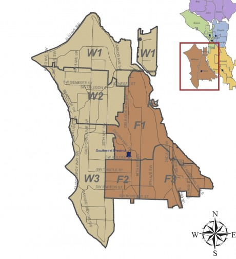

## Exploratory Analysis

The first step in the analysis involved plotting the incidents by day for the filtered West Seattle data to see the overall counts of reported incidents during the summer of 2014. The following chart plots the number of incidents reported in West Seattle by day where the solid green line indicates the Morgan Junction Community Festival, the solid red line indicates the 4th of July and the two dashed blue lines indicate the West Seattle Summer Fest duration. The date of the Summer Solstice, June 24th is denoted by a solid purple line.

### All Incidents

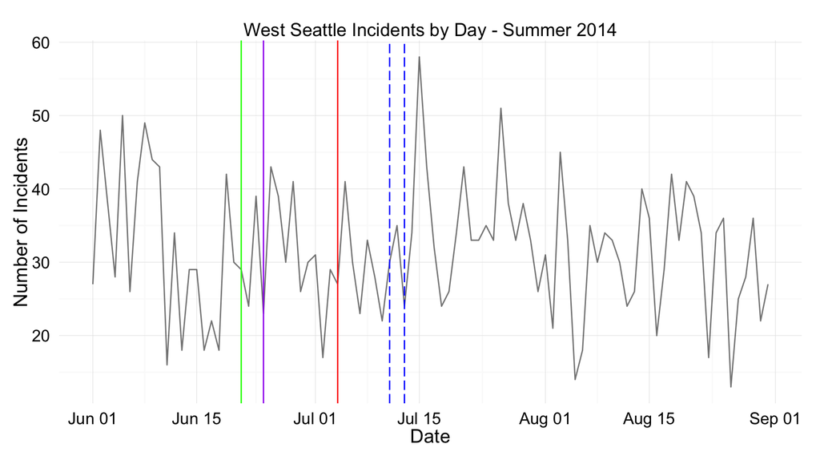

In the plot below all 4 dates and events of interest are shown by vertical black lines. The particular day of the week is distinguished by color so that it is visually easy to see if there is a higher frequency of crime on weekend days.

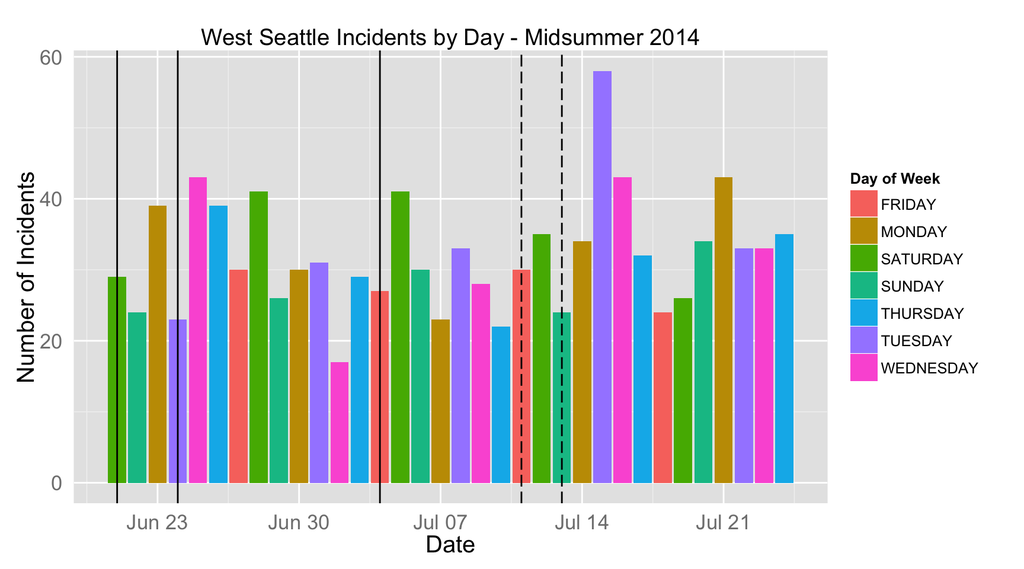

### Midsummer Incidents by Zone and Category

The next plot shows the count of midsummer incidents as well as the category of each crime.

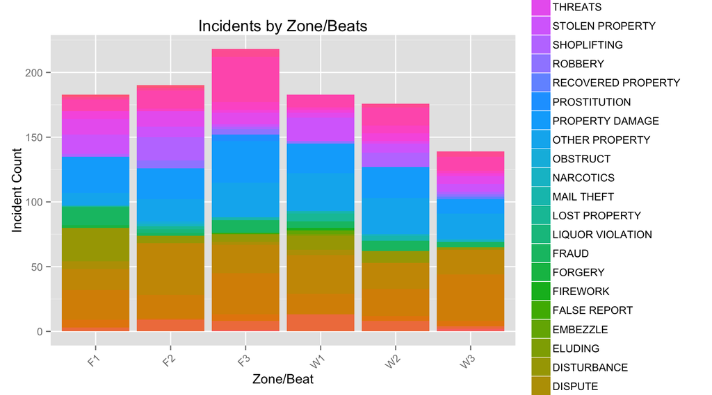

Here we see that both sectors *W2* and *W3* actually have the least amounts of crimes of all sectors within West Seattle. As these are the 2 sectors that the festivals take place in, it appears that there is no relation to criminal activity, or possibly a positive effect on crime in those areas.

This visualization, while very colorful, doesn’t clearly help us understand the proportion of crime types within a sector due to the large number of categories and color gradient changes that are diffcult to discern by the human eye. Without further breaking down the crime categories and possibly filtering out crimes that generally are not associated with celebrations, I have not discovered any insights from examining crime categorization by sector.

### Frequency of Midsummer Incidents

This pointmap + heatmap of incidents also shows how the highest frequencey of incidents occurred in sectors F2, F3 and W1. Ideally I would have included the [Seattle Police Department Beats](https://data.seattle.gov/d/nnxn-434b) shape file that is available on the Seattle data portal.

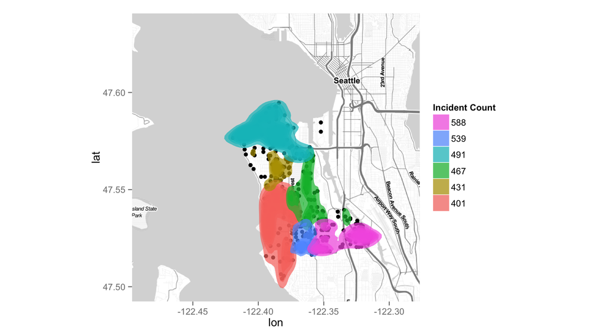

## Conclusions

All code and data is available on [github](https://github.com/aliciatb/public_scripts/tree/master/ws_crime_summer2014).

[^1]: [West Seattle Blog](http://westseattleblog.com/2015/01/see-the-new-map-as-seattle-police-redraws-beat-boundaries/) - current Southwest Precinct map and 2014 one